# Project1

Xingli Ma June 20, 2021

- Introduction
- NFL Records API and NFL Stats API
  - Retriving Tables and Quering Information from NFL Records API
  - Retriving Tables and Quering Information from NFL Stats API
- Exploratory Data Analysis
  - Tables Retrieved from NHL Records API
  - Create Plots for NHL Records
  - Numerical summaries

The following R packages are required to run the code to create this vignette.

```r
require(rmarkdown)
require(knitr)
require(dplyr)
require(tidyverse)
require(ggplot2)
require(jsonlite)
require(httr)
```

## Introduction

I created a vignette for reading and summarizing data from the National Hockey League’s (NHL) API. Three main components are present in this vignette: extracting tables and querying information from NFL Records API, extracting tables and querying information from NFL Stats API, and exploratory data analysis.

## NFL Records API and NFL Stats API

### Retriving Tables and Quering Information from NFL Records API

Create a wrapper function to return the records for a given team ID or franchise ID.

```r
team_Record <- function(teamId_OR_franchiseId, ...){

  # construct URLs
  full_url_records <- function(table_name, ...){
  base_url <- "https://records.nhl.com/site/api"
  return(paste0(base_url, table_name, ...))
}
  franchise <- full_url_records("/franchise?cayenneExp=mostRecentTeamId=", teamId_OR_franchiseId)
  franchise_teams <- full_url_records("/franchise-team-totals?cayenneExp=teamId=", teamId_OR_franchiseId)
  franchise_season <- full_url_records("/franchise-season-records?cayenneExp=franchiseId=", teamId_OR_franchiseId)
  goalie <- full_url_records("/franchise-goalie-records?cayenneExp=franchiseId=", teamId_OR_franchiseId)
  skater <- full_url_records("/franchise-skater-records?cayenneExp=franchiseId=", teamId_OR_franchiseId)
  franchise_detail <- full_url_records("/franchise-detail?cayenneExp=mostRecentTeamId=", teamId_OR_franchiseId)

 # retrieve the NHL records information and convert it to data frames
  franchise_record <- jsonlite::fromJSON(content(GET(franchise),"text"),       flatten=TRUE)$data
  franchise_teams_record <- jsonlite::fromJSON(content(GET(franchise_teams),"text"), flatten=TRUE)$data
  franchise_season_record <- jsonlite::fromJSON(content(GET(franchise_season),"text"), flatten=TRUE)$data
  goalie_record <- jsonlite::fromJSON(content(GET(goalie),"text"), flatten=TRUE)$data
  skater_record <- jsonlite::fromJSON(content(GET(skater),"text"), flatten=TRUE)$data
  franchise_detail_record <- jsonlite::fromJSON(content(GET(franchise_detail),"text"), flatten=TRUE)$data
  return(list(df1_franchise=franchise_record, df2_teams=franchise_teams_record,   df3_season=franchise_season_record, df4_goalie=goalie_record, df5_skater=skater_record, df6_adminDetail=franchise_detail_record))
}

# Query NHL records information according to the team ID or franchise ID given by a user
team_Record(1)
```

```
## $df1_franchise
##   id firstSeasonId          fullName lastSeasonId mostRecentTeamId teamAbbrev teamCommonName
## 1 23      19741975 New Jersey Devils           NA                1        NJD         Devils
##   teamPlaceName
## 1    New Jersey
##
## $df2_teams
##   id activeFranchise firstSeasonId franchiseId gameTypeId gamesPlayed goalsAgainst goalsFor
## 1  1               1      19821983          23          2        2993         8902     8792
## 2  2               1      19821983          23          3         257          634      697
##   homeLosses homeOvertimeLosses homeTies homeWins lastSeasonId losses overtimeLosses
## 1        525                 85       96      790           NA   1211            169
## 2         53                  0       NA       74           NA    120              0
##   penaltyMinutes pointPctg points roadLosses roadOvertimeLosses roadTies roadWins
## 1          44773    0.5306   3176        686                 84      123      604
```

[output cut: 600 more lines]

### Retriving Tables and Quering Information from NFL Stats API

Create a wrapper function to return the stats for a given team ID.

```r
team_Stats <- function(teamID, ...) {
  # construct URLs
  full_url_stats <- function(teamID){
  base_url <- "https://statsapi.web.nhl.com/api/v1/teams/"
  tab_name <- "/?expand=team.stats"
  return(paste0(base_url, teamID, tab_name))
  }

  # retrieve the NHL stats information and convert it to data frames
  NHLstats <- function(full_url_stats){
  return(jsonlite::fromJSON(content(GET(full_url_stats),"text"), flatten=TRUE))
  }

  teamStatsDf <- NHLstats(full_url_stats(teamID))$teams[[8]][[1]]
  teamStatsDf$splits[[1]]
}

# Query NHL stats information according to the team ID or franchise ID given by a user
team_Stats(1)
```

```
##   stat.gamesPlayed stat.wins stat.losses stat.ot stat.pts stat.ptPctg stat.goalsPerGame
## 1               56        19          30       7       45        40.2             2.589
## 2               NA      28th        29th    15th     29th        29th              26th
##   stat.goalsAgainstPerGame stat.evGGARatio stat.powerPlayPercentage stat.powerPlayGoals
## 1                    3.375          0.8293                     14.2                  22
## 2                     28th            21st                     28th                28th
##   stat.powerPlayGoalsAgainst stat.powerPlayOpportunities stat.penaltyKillPercentage
## 1                         43                         155                       71.0
## 2                       30th                        23rd                       31st
##   stat.shotsPerGame stat.shotsAllowed stat.winScoreFirst stat.winOppScoreFirst
## 1           28.7857           31.0179              0.552                 0.111
## 2              24th              22nd               22nd                  31st
##   stat.winLeadFirstPer stat.winLeadSecondPer stat.winOutshootOpp stat.winOutshotByOpp
## 1                0.737                 0.733               0.211                0.417
## 2                 19th                  28th                31st                 31st
##   stat.faceOffsTaken stat.faceOffsWon stat.faceOffsLost stat.faceOffWinPercentage
## 1               3180             1481              1699                      46.6
## 2                8th             27th              30th                      27th
##   stat.shootingPctg stat.savePctg stat.penaltyKillOpportunities stat.savePctRank
## 1                 9         0.891                          <NA>             <NA>
## 2                NA            NA                           6th             29th
##   stat.shootingPctRank team.id         team.name       team.link
## 1                 <NA>       1 New Jersey Devils /api/v1/teams/1
## 2                 24th       1 New Jersey Devils /api/v1/teams/1
```

## Exploratory Data Analysis

### Tables Retrieved from NHL Records API

```r
library(jsonlite)
library(httr)
# construct URLs
full_url_records <- function(tabl_name){
  base_url <- "https://records.nhl.com/site/api"
  return(paste0(base_url, tabl_name))
}
franchise <- full_url_records("/franchise")
franchise_totals <- full_url_records("/franchise-team-totals")
franchise_season <- full_url_records("/franchise-season-records")
goalie <- full_url_records("/franchise-goalie-records")
skater <- full_url_records("/franchise-skater-records")
admin <- full_url_records("/franchise-detail")

# retrieve the NHL records information and convert it to data frames
NHLrecords <- function(full_url_records){
  return(jsonlite::fromJSON(content(GET(full_url_records),"text"), flatten=TRUE))
}
franchiseDf <- NHLrecords(franchise)$data
franchise_totalsDf <- NHLrecords(franchise_totals)$data
franchise_seasonsDf <- NHLrecords(franchise_season)$data
goalieDf <- NHLrecords(goalie)$data
skaterDf <- NHLrecords(skater)$data
adminDf <- NHLrecords(admin)$data
```

### Create Plots for NHL Records

franchise_totals histogram plot on a newly created variable win percentage.

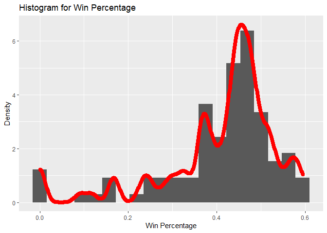

```r
# Create a new variable win percentage
franchise_totalsDf <- franchise_totalsDf %>% mutate(winPctg=wins/gamesPlayed)

# Create a histogram plot
d <- ggplot(franchise_totalsDf, aes(x=winPctg))
d + geom_histogram(bins=20, aes(y=..density..)) +
  geom_density(stat="density", adjust=0.4, lwd=3, colour= "red") +
  xlab("Win Percentage") + ylab("Density") +
  ggtitle("Histogram for Win Percentage")
```

Bar plot on franchise teams totals information.

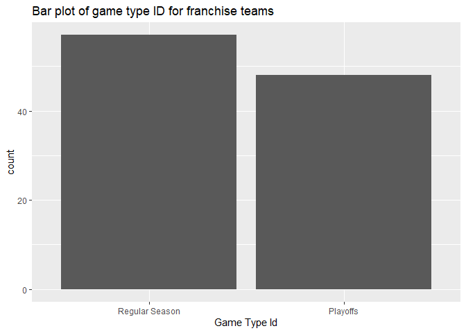

```r
# Convert categorical variable to factors
franchise_totalsDf$gameTypeId <- as.factor(franchise_totalsDf$gameTypeId)
# Renaming factor levels
levels(franchise_totalsDf$gameTypeId) <- c("Regular Season", "Playoffs")
# Create bar plot
g <- ggplot(data=franchise_totalsDf, aes(x=gameTypeId))
g + geom_bar() +
  labs(x="Game Type Id", title = "Bar plot of game type ID for franchise teams") +
  scale_x_discrete(labels = c("Regular Season", "Playoffs"))
```

Scatter plot on franchise teams totals information.

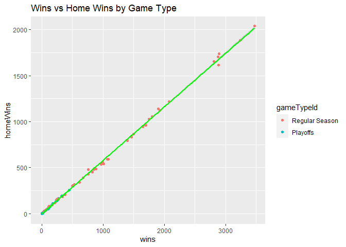

```r
f <- ggplot(franchise_totalsDf, aes(x = wins, y = homeWins, group = gameTypeId))
f + geom_point(aes(color= gameTypeId)) +
  geom_smooth(method=lm, color="green") +
  ggtitle("Wins vs Home Wins by Game Type")
```

Combine two tables and create a new variable to indicate records from different tables.

```r
# Create an indicator variable
goalieDf_new <- cbind(goalieDf,df=rep(1,1078))
skaterDf_new <- cbind(skaterDf,df=rep(2,17209))
# Vertically combine goalie and skater tables
goalie_skater <- bind_rows(goalieDf_new, skaterDf_new)
goalie_skater_new <- filter(goalie_skater, gameTypeId == 2, activePlayer == TRUE)
```

Scatter plot on goalie and skater information.

[figure not shown]

```r
# Convert categorical variable to factors
goalie_skater_new$df <- as.factor(goalie_skater_new$df)
# Renaming factor levels
levels(goalie_skater_new$df) <- c("goalie", "skater")
# Create scatter plot
s <- ggplot(goalie_skater_new, aes(x=gamesPlayed,y=seasons, group=df))
s + geom_point(aes(color= df)) +
  geom_smooth(method=lm, color="green") +
  ggtitle("Games Played vs Goals by Game Type")
```

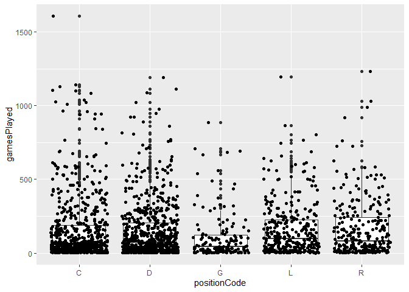

```r
f <- ggplot(goalie_skater_new, aes(x = positionCode, y = gamesPlayed))
f + geom_boxplot() +
   geom_jitter(geom="point")
```

### Numerical summaries

Numerical summaries on wins, losses, and ties for each franchise by game type.

```r
win_loss_tie <- franchise_totalsDf %>% group_by(franchiseId, gameTypeId) %>% summarise(win.avg=round(mean(wins),2), loss.avg=round(mean(losses),2), tie.avg=round(mean(ties),2), wl_ratio=round(wins/losses),2)
knitr::kable(win_loss_tie )
```

| franchiseId | gameTypeId | win.avg | loss.avg | tie.avg | wl_ratio | 2 |
| --- | --- | --- | --- | --- | --- | --- |
| 1 | Regular Season | 3473.00 | 2302.00 | 837.00 | 2 | 2 |
| 1 | Playoffs | 444.00 | 321.00 | 8.00 | 1 | 2 |
| 2 | Regular Season | 1.00 | 5.00 | 0.00 | 0 | 2 |
| 3 | Regular Season | 134.50 | 126.00 | 34.50 | 1 | 2 |
| 3 | Regular Season | 134.50 | 126.00 | 34.50 | 0 | 2 |
| 3 | Playoffs | 18.00 | 17.00 | 6.00 | 1 | 2 |
| 4 | Regular Season | 25.50 | 49.00 | 0.50 | 1 | 2 |
| 4 | Regular Season | 25.50 | 49.00 | 0.50 | 0 | 2 |
| 5 | Regular Season | 1000.00 | 943.00 | 261.00 | 1 | 2 |
| 5 | Regular Season | 1000.00 | 943.00 | 261.00 | 1 | 2 |
| 5 | Regular Season | 1000.00 | 943.00 | 261.00 | 1 | 2 |
| 5 | Playoffs | 89.00 | 97.33 | 1.33 | 1 | 2 |
| 5 | Playoffs | 89.00 | 97.33 | 1.33 | 1 | 2 |
| 5 | Playoffs | 89.00 | 97.33 | 1.33 | 1 | 2 |
| 6 | Regular Season | 3241.00 | 2403.00 | 791.00 | 1 | 2 |
| 6 | Playoffs | 332.00 | 337.00 | 6.00 | 1 | 2 |
| 7 | Regular Season | 271.00 | 260.00 | 91.00 | 1 | 2 |
| 7 | Playoffs | 20.00 | 21.00 | 9.00 | 1 | 2 |
| 8 | Regular Season | 127.50 | 201.00 | 63.50 | 1 | 2 |
| 8 | Regular Season | 127.50 | 201.00 | 63.50 | 1 | 2 |
| 8 | Playoffs | 6.00 | 11.00 | 1.00 | 1 | 2 |
| 9 | Regular Season | 35.50 | 79.00 | 13.50 | 1 | 2 |
| 9 | Regular Season | 35.50 | 79.00 | 13.50 | 0 | 2 |
| 9 | Playoffs | 1.00 | 2.00 | 1.00 | 0 | 2 |
| 10 | Regular Season | 2883.00 | 2716.00 | 808.00 | 1 | 2 |
| 10 | Playoffs | 244.00 | 266.00 | 8.00 | 1 | 2 |
| 11 | Regular Season | 2812.00 | 2761.00 | 814.00 | 1 | 2 |
| 11 | Playoffs | 268.00 | 275.00 | 5.00 | 1 | 2 |
| 12 | Regular Season | 996.33 | 858.00 | 271.67 | 1 | 2 |
| 12 | Regular Season | 996.33 | 858.00 | 271.67 | 1 | 2 |

[output cut: 75 more lines]